# EDA and Data cleaning for Assignment 1

Yiran Jing 460244129

25 September, 2020

# Executive Summary

This report includes exploratory data analysis, outlier and missing value detection based on tech_biom and dict_biom Rdataset.

There are 4 low variance variables (“DIABBC”, “HCHOLBC”, “HSUGBC”, and “HYPBC”) with too less information compared with other columns. Secondly, `EXLWMBC`, `EXLWVBC`, `EXLWTBC` are exerciese minuates measurements, and they should be continuous variables instead of categorical variables, also the extreme values such as “9996”, “9999” within these columns are wired, so be treated as outliers. Thirdly, there are some logical inconsistencies in column `FEMLSBC`, `DIABBC` and `BDYMSQ04`. In the section of outlier dectection, I check outliers based on both visualization and box plot statistics, and add `XXX_OUT` outlier indicator columns. The summary of outliers can be found in table 3.1. In terms of messing values, I produce visualization on the missingness amount and pattern for each variables and the combinations of missingness, also summarizing the prevalence of missingness in table 4.1.

Since missing value in the dataset are not at random with patterns, and the missing ratio is quite large, I didnot delete any column or row, since the missingness implies certain information and I want to keep as much information as possible. The final complete dataset has 12153 rows with 106 columns.

The research topic of our group is “What the kinds of factors related to **Diabetes**”, thus `DIABBC`(Whether has diabetes mellitus) and `GLUCFPD`(Fasting plasma glucose status (mmol/L)) can be the good response variables.

In next step, I will perform a PCA with missing values to explore the correlation between variables using R package *`missMDA`*. Moreover, I will delete some high correlated variables, for example, “EXLWMBC”, “EXLWVBC”, “EXLWTBC” are highly correlated with each other (corr > 97%).

```r
# Load objects in study1.RData into my workspace
load(file = "tech_data.Rdata")
```

# EDA

Finding:

- Low variance variables:
  1. There are 4 low-variance variables “DIABBC”, “HCHOLBC”, “HSUGBC”, and “HYPBC” based on self-defined selection rules.
  2. The low variance variables selection rules:
     1. if factor has frequency less than 1% (i.e. less than 121 rows) or if factor has frequency more than 90%
     2. and if the unique values of that column are less than 5
- Mismatches between the data and dictionary:
  1. `EXLWMBC`, `EXLWVBC`, `EXLWTBC` are exerciese minuates measurements, should be mentioned as continuous variables,
  2. Also the extreme values such as “9996”, “9999” within these columns are wired, thus I treat these value as outliers.
- Logical inconsistencies
  1. `FEMLSBC` (Female life stages): based on dictionary, FEMLSBC = 6 means none of these apply, it can have special meaning or indicating missing as well, which should be differ from value 1 to 5. And thus, it is locical inconsistency.
  2. `BDYMSQ04` (Whether currently on a diet): this variable by definition given in dictionary should be binary variable, with only 2 values. But this column includes also show different diet type. (1 means Currently on a diet to lose weight, 2 means Currently on a diet for health reasons etc.). It is logical incinsistency and should be separate into two columns: `diet or not` and `diet type`
- Missing value detection based on data visualization (in the missing value detection section below)

### Low variance variables

Low-variance variales both continuous and categorical variables. The column has `relatively less information`, compared with other columns.

The low variance variables selection rules: 1. if factor has frequency less than 1% (i.e. less than 121 rows) or if factor has frequency more than 90% 2. and if the unique values of that column are less than 5

Based on the rules above, we find 4 low-variance variables

- **“DIABBC”** Whether has diabetes mellitus
- **“HCHOLBC”** Whether has high cholesterol
- **“HSUGBC”** Whether has high sugar levels in blood/urine
- **“HYPBC”** Whether has hypertensive disease

They are all categorical variables, and we will delete them in the dataset, since they contain too less information and not useful in our dataset.

| DIABBC | counts | freq |
| --- | --- | --- |
| 1 | 597 | 4.91 |
| 3 | 50 | 0.41 |
| 5 | 11506 | 94.68 |

| HCHOLBC | counts | freq |
| --- | --- | --- |
| 1 | 877 | 7.22 |
| 2 | 39 | 0.32 |
| 3 | 439 | 3.61 |
| 5 | 10798 | 88.85 |

| HSUGBC | counts | freq |
| --- | --- | --- |
| 1 | 34 | 0.28 |
| 2 | 30 | 0.25 |
| 3 | 293 | 2.41 |
| 5 | 11796 | 97.06 |

| HYPBC | counts | freq |
| --- | --- | --- |
| 1 | 1428 | 11.75 |
| 2 | 29 | 0.24 |
| 3 | 471 | 3.88 |
| 5 | 10225 | 84.14 |

### Mismatches between the data and dictionary

- `"EXLWMBC"`, `"EXLWVBC"`, `“EXLWTBC”` (Total):
  1. They are exerciese minuates in last week, so they should be mentioned as continuous variables in the dictionary, not categorical variable.
  2. Also the extreme values such as “9996”, “9999” within these columns are wired, since it is impossible for ppl to exercise so much within one week. So highly likely these values are missing or incorrect. I treat them as outliers.
- Remedy:
  1. Convert factor format to numeric format
  2. Add indicator columns for these three columns if their values are 9996 or 9999. called `EXLWTBC_OUT`, `EXLWMBC_OUT`, and `EXLWVBC_OUT`

```r
new_tech_biom = tech_biom
### Convert factor format to numeric format
new_tech_biom[,"EXLWMBC"] = as.numeric(as.character(new_tech_biom[,"EXLWMBC"]))
new_tech_biom[,"EXLWVBC"] = as.numeric(as.character(new_tech_biom[,"EXLWVBC"]))
new_tech_biom[,"EXLWTBC"] = as.numeric(as.character(new_tech_biom[,"EXLWTBC"]))
```

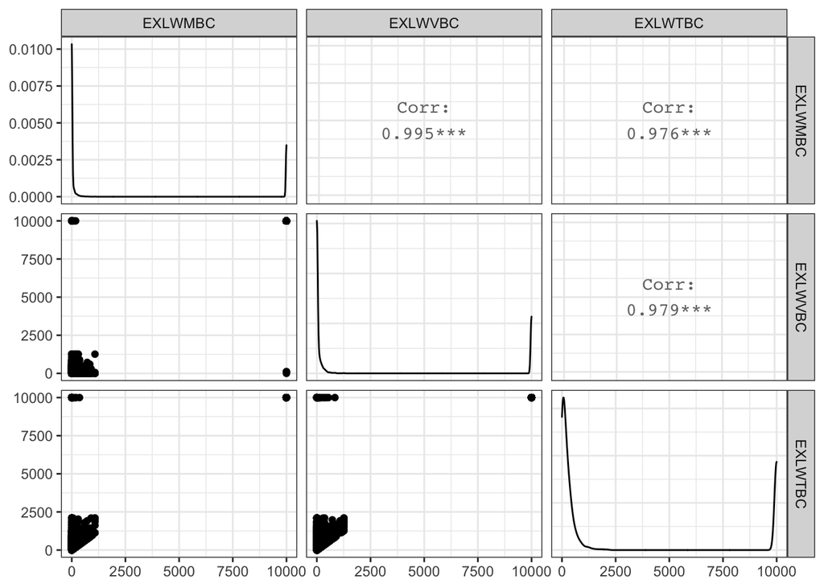

From the pair plots above we can see that:

1. The extreme values such as “9996”, “9999” show above are outliers (incorrect values), we add indicator columns for these three columns if their values are 9996 or 9999. called `EXLWTBC_OUT`, `EXLWMBC_OUT`, and `EXLWVBC_OUT` if the value larger than 1500 mins.
2. “EXLWMBC”, “EXLWVBC”, “EXLWTBC” are highly correlated with each other (corr > 97%), so we shall use only one of columns in the final dataset

```r
# add outlier indicator
new_tech_biom <- transform(new_tech_biom, EXLWMBC_OUT = ifelse(EXLWMBC > 1500, TRUE, FALSE))
new_tech_biom <- transform(new_tech_biom, EXLWVBC_OUT = ifelse(EXLWVBC > 1500, TRUE, FALSE))
new_tech_biom <- transform(new_tech_biom, EXLWTBC_OUT = ifelse(EXLWTBC > 1500, TRUE, FALSE))
```

### Logical inconsistencies

There are something remotely problematic with the data.

- `FEMLSBC` (Female life stages): based on dictionary, FEMLSBC = 6 means none of these apply, it can have special meaning or indicating missing as well, which should be differ from value 1 to 5. And thus, it is locical inconsistency.
- `BDYMSQ04` (Whether currently on a diet): this variable by definition given in dictionary should be binary variable, with only 2 values (Yes or No). But this column includes also show different diet type. (1 means Currently on a diet to lose weight, 2 means Currently on a diet for health reasons etc.). It is logical incinsistency and should be separate into two columns: `diet or not` and `diet type`
- `DIABBC` (Whether has diabetes mellitus): this variable by definition given in dictionary should be binary variable, with only 2 values. But this column in tech_biom has 3 values: (1. Ever told has diabetes mellitus, still current and long term; 3. Ever told has diabetes mellitus, not current; 5. Never told has diabetes mellitus). It is logical incinsistency and should be separate into two columns: `current diabetes or not` and `diabetes history or not`

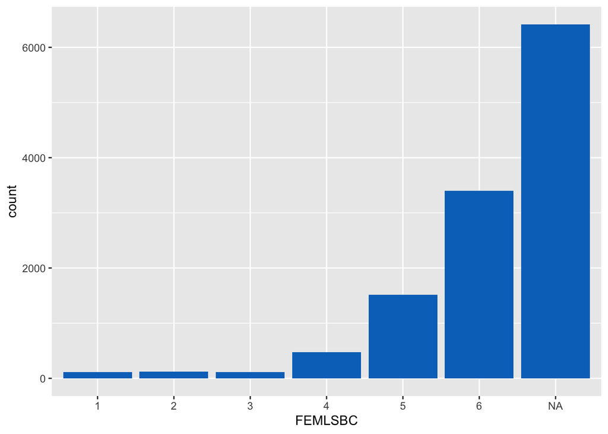

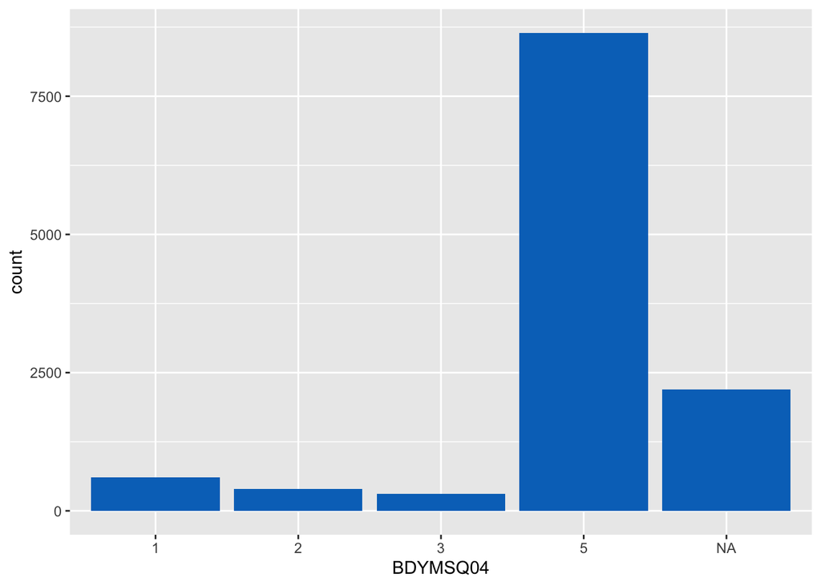

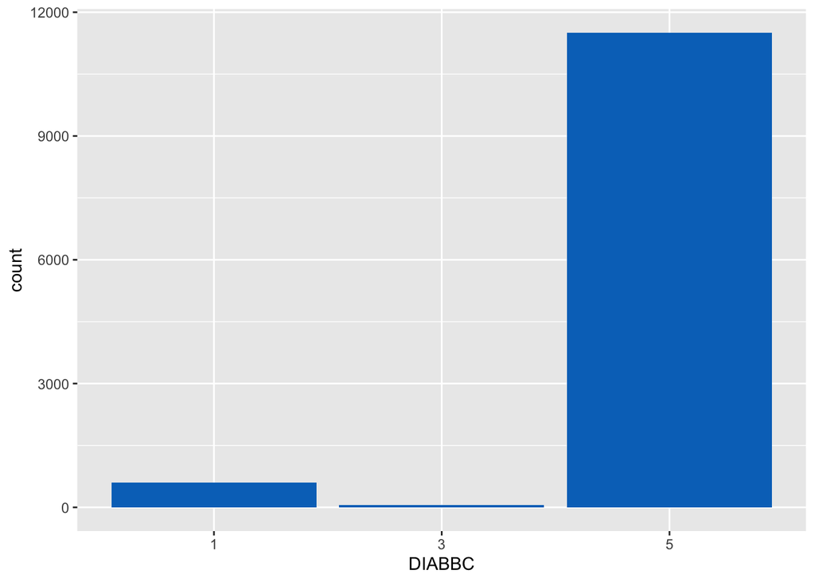

```r
problem_col = c("FEMLSBC", "BDYMSQ04", "DIABBC")

result_list1 = plot_selected_col(tech_biom, problem_col)
```

### Check missing pattern of CVDMEDST

- `CVDMEDST` (Dyslipidaemia status, given Persons aged 18 years and over who participated in the biomedical component and fasted for 8 hours or more)

The missing value reported above are **not at random**, and there are patterns in the missing data. In this report, I give an example of CVDMEDST Since CVDMEDST has the most missing value, we visualization to find the reason of missing.

Based on the definition of CVDMEDST, it is related to age and fasted state, the figure 1.1 shows the missingness interaction among these 3 variables. From figure 1.1, we can see that 8022 cases missing in both “CVDMEDST”, “FASTSTAD”. From Figure 1.3, we can confirm that all people who didnot fasted, have missing value in CVDMEDST, which is logically correct. And some fasted people with missing value in CVDMEDST, since their ages are less than 18, which can be confirmed by figure 1.2.

Therefore, we shouldnot delete `CVDMEDST` column or rows with missing value, as they stands for specific group with specific information.

Figure 1.1

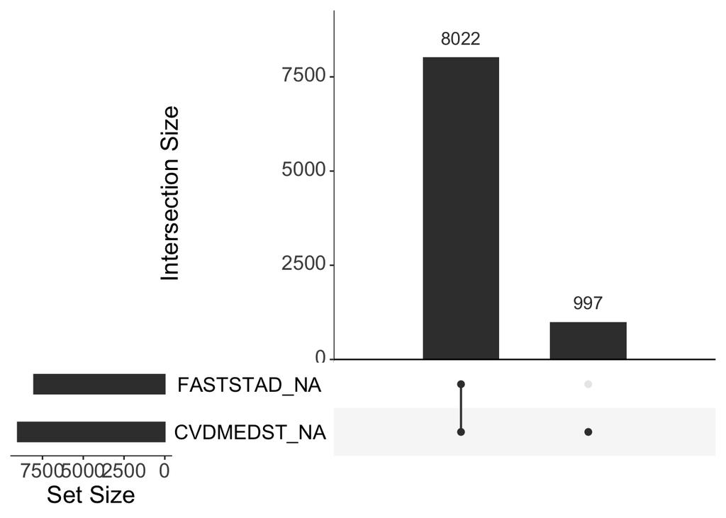

```r
# Figure 1.1
selected_col = c("AGEC", "CVDMEDST", "FASTSTAD")
gg_miss_upset(tech_biom[, selected_col], text.scale = 2)
```

figure 1.2

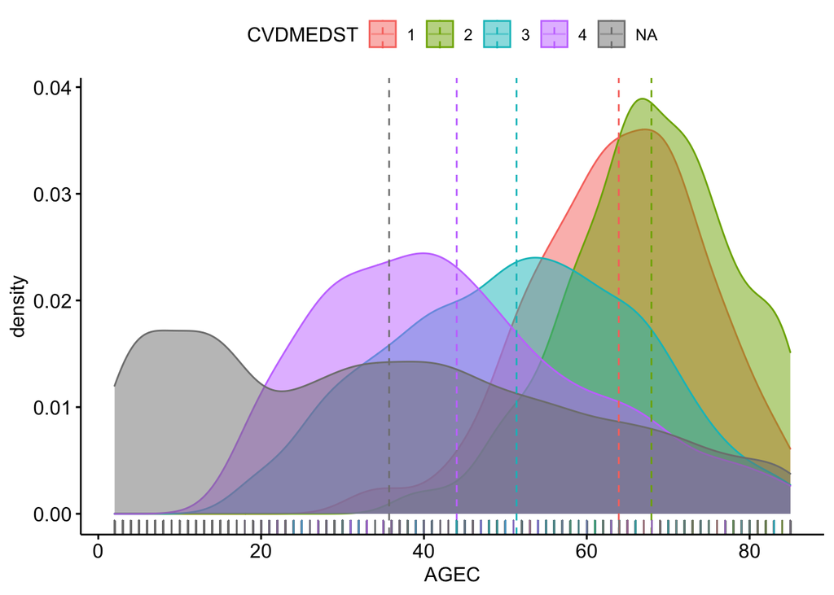

```r
# figure 1.2
ggdensity(tech_biom, x = "AGEC",
   add = "mean", rug = TRUE,
   color = "CVDMEDST", fill = "CVDMEDST",
   #palette = c("#0073C2FF", "#FC4E07")
         )
```

Figure 1.3

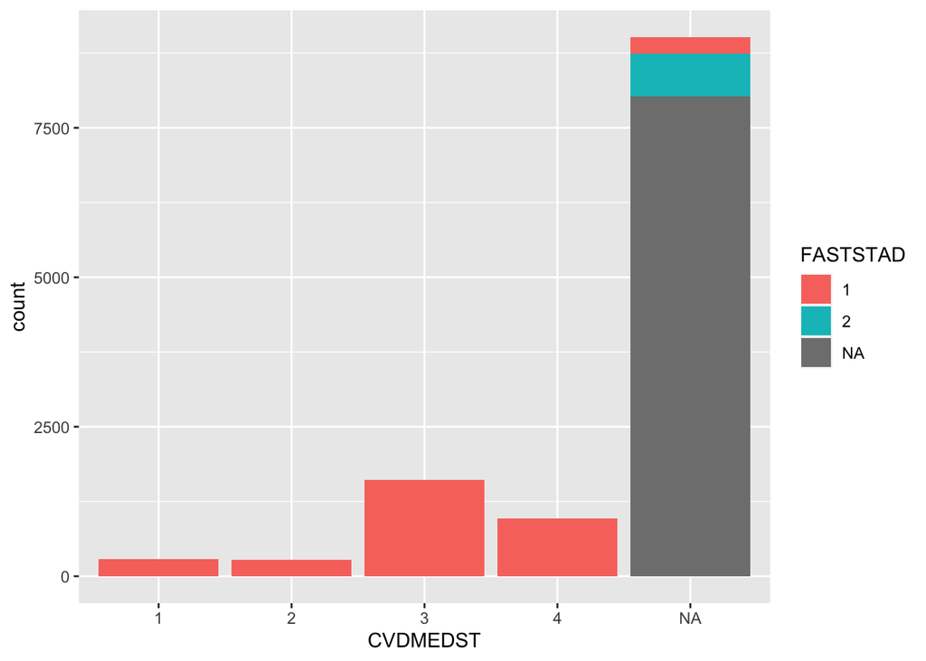

```r
### Figure 1.3
# 1. Fasted (8 hours or more)
# 2. Did not fast
# stacked bar chart
ggplot(tech_biom,
       aes(x = CVDMEDST,
           fill = FASTSTAD),
      title = "CVDMEDST VS Fasted") +
  geom_bar(position = "stack")
```

# Outlier detection

### Outliers in BMISC

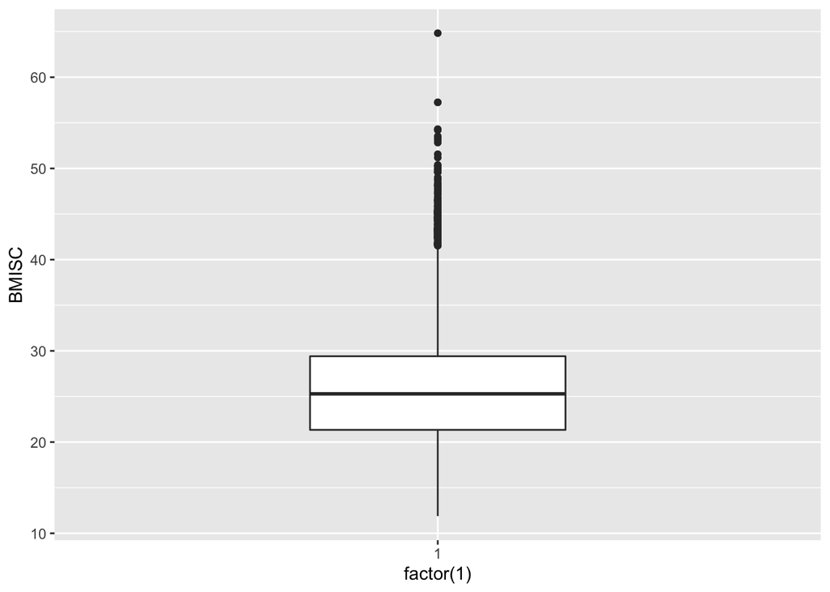

```r
ggplot(new_tech_biom, aes(x = factor(1), y = BMISC)) +
  geom_boxplot(width = 0.4, fill = "white")
```

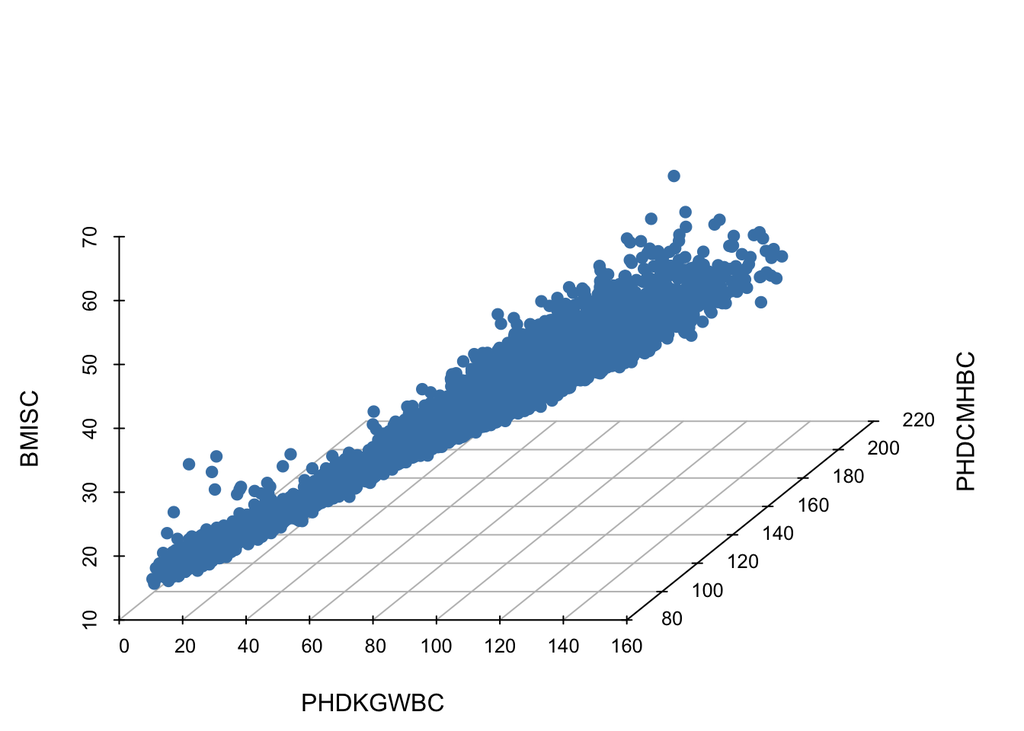

```r
## Plot PHDKGWBC Measured weight (kg) VS PHDCMHBC Measured height (cm) VS BMISC Body mass index (BMI)
sub_col = c("PHDKGWBC", "PHDCMHBC", "BMISC")
scatterplot3d(
  new_tech_biom[,sub_col], pch = 19, color = "steelblue",
   grid = TRUE, box = FALSE,
   mar = c(3, 3, 0.5, 3)
  )
```

### Detect all outliers in numerical columns

We define outliers based on Box Plot Statistics, the values of any data points which lie beyond the extremes of the whiskers

```r
is_outlier <- function(x) { return(x%in%boxplot(x, plot = FALSE)$out); }
out_name <- function(x) { return(paste0(x, "_OUT")); } # add corresponding outlier indicator columns
```

```r
sub_col = c(filter(types_biom, variable_type %in% c("continuous"))$variable_name)
sub_cont = new_tech_biom[,sub_col]
```

```r
sub_cont_out  <- sub_cont %>%
             mutate_all(.funs = is_outlier) %>%
             rename_with(.fn=out_name)
new_tech_biom <- bind_cols(new_tech_biom, sub_cont_out)
```

### Table summarizing the prevalence of outliers in the dataset

We use outlier indicator columns to summarizing the prevalence of outliers

Table 3.1

Table 3.1: Outliers by continuous variable

|  | EXLWMBC_OUT | EXLWVBC_OUT | EXLWTBC_OUT | BMISC_OUT | AGEC_OUT | PHDKGWBC_OUT | PHDCMHBC_OUT | PHDCMWBC_OUT | ADTOTSE_OUT | DIASTOL_OUT | SLPTIME_OUT | SYSTOL_OUT |
| --- | --- | --- | --- | --- | --- | --- | --- | --- | --- | --- | --- | --- |
|  | Mode :logical | Mode :logical | Mode :logical | Mode :logical | Mode :logical | Mode :logical | Mode :logical | Mode :logical | Mode :logical | Mode :logical | Mode :logical | Mode :logical |
|  | FALSE:9424 | FALSE:9415 | FALSE:9266 | FALSE:11978 | FALSE:12153 | FALSE:11890 | FALSE:11224 | FALSE:12106 | FALSE:12026 | FALSE:12075 | FALSE:11983 | FALSE:11933 |
|  | TRUE :2729 | TRUE :2738 | TRUE :2887 | TRUE :175 | NA | TRUE :263 | TRUE :929 | TRUE :47 | TRUE :127 | TRUE :78 | TRUE :170 | TRUE :220 |

# Missing values

Finding:

- There are 40 variables have missing values. Overall 54 columns, only 14 variables have no missing value.
- The overall percentage of missing value is 34.1%, which is high, and there are 21 variables with missing percentage more than 60%.
- `CVDMEDST` has the most missing percentage (74%), and there are 278 cases where only missing CVDMEDST
- Combinations of missingness of the variables:
  1. There are 8022 cases where 21 variables have missing values.
  2. There are 630 cases where 7 variables have missing.
  3. There are 77 cases where 20 variables have missing values. 37 cases have missing 2 variables.
  4. There are some cases (less than 10), have missing value combinations. And we can remove these since they could have little impact on the result.

### Visualization to determine missingness amount and pattern

We only consider the dataset, exclude the indicator columns (such as XXX_MISS, XXX_OUT)

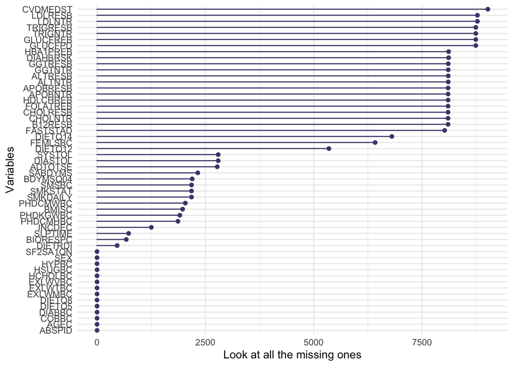

```r
# figure 4.1
# Visualizing relative amounts of missingness
gg_miss_var(visual_dat) + labs(y = "Look at all the missing ones")
```

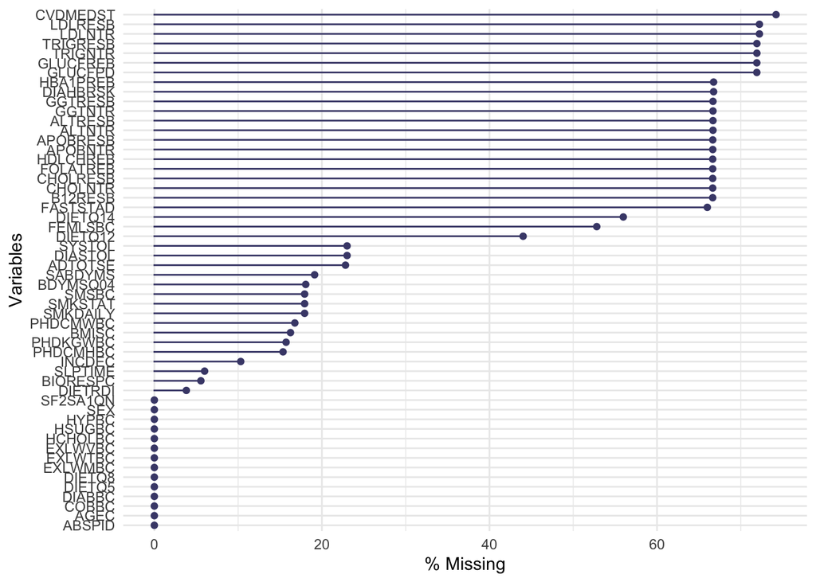

```r
# figure 4.2
# Visualizing the percentage of missings
gg_miss_var(visual_dat, show_pct = TRUE)
```

From the figures above, we can see that:

1. There are some variables have large amount of missing data.
   - `CVDMEDST` has the most missing percentage (74%)
   - there are 20 more variables with relatively high missing value (more than 7500 rows are missing, more than 60%)

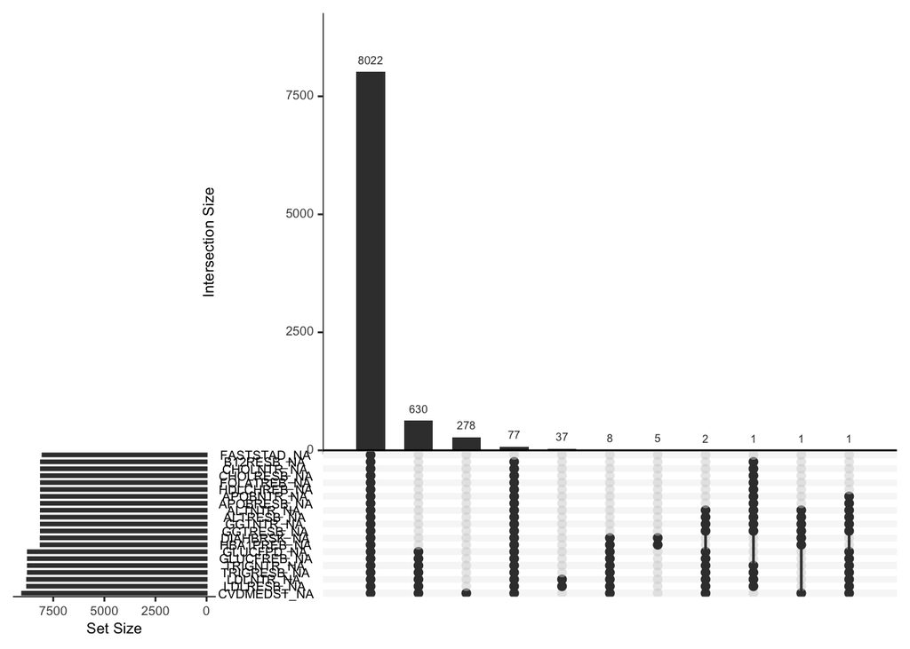

```r
# figure 4.3
# Visualizing Combinations of missingness of the variables
gg_miss_upset(visual_dat, text.scale = 1, nsets = 21)
```

From the figure above, we can see that:

- `CVDMEDST` has the most missing values, and there are 278 cases where only missing `CVDMEDST`
- There are 8022 cases where 21 variables have missing values.
- There are 630 cases where 7 variables have missing.
- There are 77 cases where 20 variables have missing values. 37 cases have missing 2 variables.
- There are some cases (less than 10), have missing value combinations. And we can remove these since they could have little impact on the result.

### Table susmmaring the prebalence of missingness

#### Table 4.1: Missing values by variable

The table 4.1 give us the number of missing value and missing percentage for each variable, (summarizing the information included in figure 4.1 and 4.2).

```r
# Table 4.1: Observe individually how many missing values a variable has.
# generate HTML table outside
miss_var_summary(visual_dat) %>%
    kable(booktabs = TRUE, digits = 2,
          col.names = c("Variable","number of missing values",
                        "% of missing values"),
          caption = "Missing values by variable")  %>%
    kable_styling(bootstrap_options = "striped", latex_options = "HOLD_position")
```

Missing values by variable

| Variable | number of missing values | % of missing values |
| --- | --- | --- |
| CVDMEDST | 9019 | 74.21 |
| LDLNTR | 8778 | 72.23 |
| LDLRESB | 8778 | 72.23 |
| TRIGNTR | 8741 | 71.92 |
| TRIGRESB | 8741 | 71.92 |
| GLUCFPD | 8740 | 71.92 |
| GLUCFREB | 8740 | 71.92 |
| DIAHBRSK | 8113 | 66.76 |
| HBA1PREB | 8113 | 66.76 |
| ALTNTR | 8104 | 66.68 |
| ALTRESB | 8104 | 66.68 |
| GGTNTR | 8104 | 66.68 |
| GGTRESB | 8104 | 66.68 |
| APOBNTR | 8101 | 66.66 |
| APOBRESB | 8101 | 66.66 |
| B12RESB | 8100 | 66.65 |
| CHOLNTR | 8100 | 66.65 |
| CHOLRESB | 8100 | 66.65 |
| FOLATREB | 8100 | 66.65 |
| HDLCHREB | 8100 | 66.65 |
| FASTSTAD | 8022 | 66.01 |
| DIETQ14 | 6803 | 55.98 |
| FEMLSBC | 6418 | 52.81 |
| DIETQ12 | 5350 | 44.02 |
| DIASTOL | 2796 | 23.01 |
| SYSTOL | 2796 | 23.01 |
| ADTOTSE | 2773 | 22.82 |
| SABDYMS | 2325 | 19.13 |
| BDYMSQ04 | 2196 | 18.07 |
| SMSBC | 2180 | 17.94 |
| SMKDAILY | 2180 | 17.94 |
| SMKSTAT | 2180 | 17.94 |
| PHDCMWBC | 2038 | 16.77 |
| BMISC | 1975 | 16.25 |
| PHDKGWBC | 1911 | 15.72 |
| PHDCMHBC | 1867 | 15.36 |
| INCDEC | 1253 | 10.31 |
| SLPTIME | 729 | 6.00 |
| BIORESPC | 675 | 5.55 |
| DIETRDI | 464 | 3.82 |
| ABSPID | 0 | 0.00 |
| AGEC | 0 | 0.00 |
| COBBC | 0 | 0.00 |
| EXLWTBC | 0 | 0.00 |
| EXLWMBC | 0 | 0.00 |
| EXLWVBC | 0 | 0.00 |
| SF2SA1QN | 0 | 0.00 |
| DIABBC | 0 | 0.00 |
| HCHOLBC | 0 | 0.00 |
| HSUGBC | 0 | 0.00 |
| HYPBC | 0 | 0.00 |
| DIETQ5 | 0 | 0.00 |
| DIETQ8 | 0 | 0.00 |
| SEX | 0 | 0.00 |

### Produce dataset that is complete

The missing value reported above are **not at random**, and there are patterns in the missing data. For example, as discuessed in the EDA part, the missingness of `CVDMEDST` is due to person not fasted or age under 18. Similarly,both `LDLRESB` and `LDLNTR` exclude persons with fasting triglycerides results ≥4.5mmol/L.

So we should not delete these columns with high missing ratio, as the missingness implies certain information, and also we shouldnot delete the rows with missing value, as they stands for specific groups (such as the person under 18 years old). Also, most modeling functions in R offer options for dealing with missing values. Therefore, to avoid loss informtion, I donot delete any row or columns with NA. Just filling them with value 0, and keep the missing value indicator in the final dataset. Combining with the indicator columns for missing value and outliers, the final complete dataset has 12153 rows with 106 columns.

The **most missing variables have high correlation, we will perform a PCA with missing values to explore the correlation between variables.** using R package *`library(missMDA)`* in the next stage

Variable explaination

- `LDLRESB` (Fasting LDL cholesterol and the persons with triglycerides results ≥4.5mmol/L were excluded).
- `LDLNTR` (Fasting LDL cholesterol status and All persons with fasting triglycerides results ≥4.5mmol/L were excluded .)
- `CVDMEDST` (Dyslipidaemia status, given Persons aged 18 years and over who participated in the biomedical component and fasted for 8 hours or more)

```r
new_tech_biom <- new_tech_biom %>% mutate_all(funs(replace_na(.,0))) # replace NA with 0
```

```r
dim(new_tech_biom) # the size of complete dataset
```

```
## [1] 12153   106
```

The size of complete dataset is 12153, 106.

# Save result

called `clean_data.Rdata`

```r
save(new_tech_biom, dict_biom,
     file = "clean_data.Rdata")
```